# 19_squeeze_2D

## 19_squeeze_2D

#### Question

1. A video-game developer is hoping to apply a [squeeze map](https://en.wikipedia.org/wiki/Squeeze_mapping) to a set of points by using matrix multiplication. Interestingly, during a squeeze map, the area remains constant.

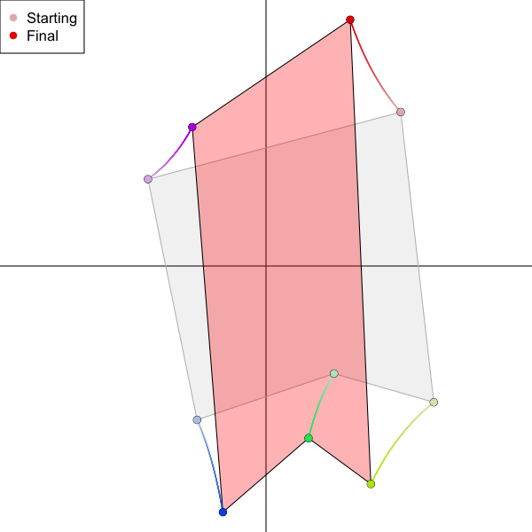

   The starting points are stored as rows in a 5 $\times$ 2 matrix $S$.

   $$S=\begin{bmatrix}
   4.683 & 5.35\\
   5.832 & -4.735\\
   2.365 & -3.74\\
   -2.396 & -5.348\\
   -4.102 & 3.017
   \end{bmatrix}$$

   The squeeze matrix can be found by using $k=0.625$ in the formula below.

   $$T~=~\begin{bmatrix}
   k & 0\\
   0 & 1/k
   \end{bmatrix}$$

   The final points (in matrix $F$) are found by multiplying $S\cdot T$.

   $$F=S\cdot T$$

   That multiplication can be done using the diagram below.

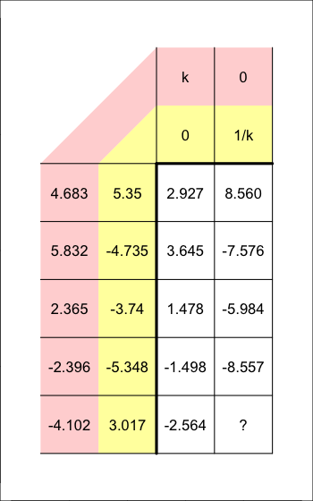

   What is the new y coordinate when point $(-4.102, 3.017)$ undergoes the squeeze transformation with $k=0.625$?

#### Question

2. A video-game developer is hoping to apply a [squeeze map](https://en.wikipedia.org/wiki/Squeeze_mapping) to a set of points by using matrix multiplication. Interestingly, during a squeeze map, the area remains constant.

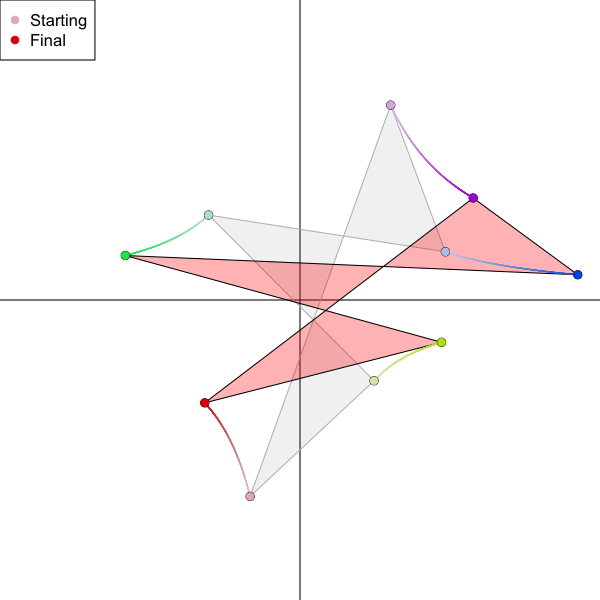

   The starting points are stored as rows in a 5 $\times$ 2 matrix $S$.

   $$S=\begin{bmatrix}
   -1.462 & -5.758\\
   2.172 & -2.367\\
   -2.681 & 2.491\\
   4.263 & 1.413\\
   2.658 & 5.712
   \end{bmatrix}$$

   The squeeze matrix can be found by using $k=1.91$ in the formula below.

   $$T~=~\begin{bmatrix}
   k & 0\\
   0 & 1/k
   \end{bmatrix}$$

   The final points (in matrix $F$) are found by multiplying $S\cdot T$.

   $$F=S\cdot T$$

   That multiplication can be done using the diagram below.

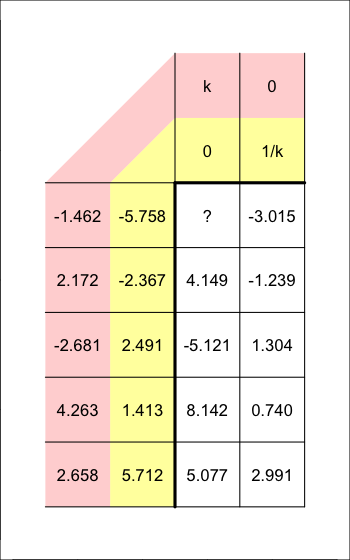

   What is the new x coordinate when point $(-1.462, -5.758)$ undergoes the squeeze transformation with $k=1.91$?

#### Question

3. A video-game developer is hoping to apply a [squeeze map](https://en.wikipedia.org/wiki/Squeeze_mapping) to a set of points by using matrix multiplication. Interestingly, during a squeeze map, the area remains constant.

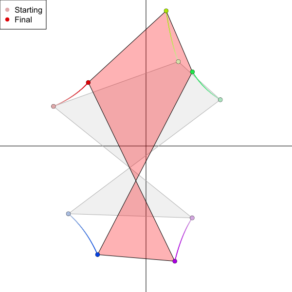

   The starting points are stored as rows in a 5 $\times$ 2 matrix $S$.

   $$S=\begin{bmatrix}
   -5.866 & 2.513\\
   2.048 & 5.348\\
   4.712 & 2.934\\
   -4.922 & -4.296\\
   2.927 & -4.557
   \end{bmatrix}$$

   The squeeze matrix can be found by using $k=0.624$ in the formula below.

   $$T~=~\begin{bmatrix}
   k & 0\\
   0 & 1/k
   \end{bmatrix}$$

   The final points (in matrix $F$) are found by multiplying $S\cdot T$.

   $$F=S\cdot T$$

   That multiplication can be done using the diagram below.

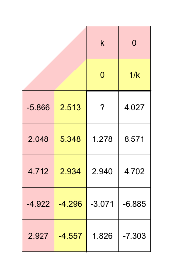

   What is the new x coordinate when point $(-5.866, 2.513)$ undergoes the squeeze transformation with $k=0.624$?

#### Question

4. A video-game developer is hoping to apply a [squeeze map](https://en.wikipedia.org/wiki/Squeeze_mapping) to a set of points by using matrix multiplication. Interestingly, during a squeeze map, the area remains constant.

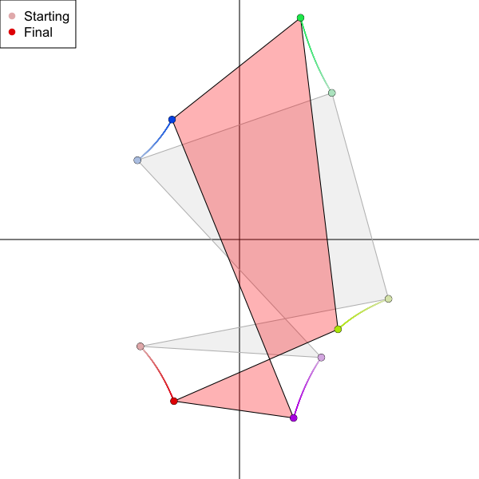

   The starting points are stored as rows in a 5 $\times$ 2 matrix $S$.

   $$S=\begin{bmatrix}
   -3.857 & -4.156\\
   5.796 & -2.309\\
   3.593 & 5.702\\
   -3.971 & 3.084\\
   3.183 & -4.589
   \end{bmatrix}$$

   The squeeze matrix can be found by using $k=0.661$ in the formula below.

   $$T~=~\begin{bmatrix}
   k & 0\\
   0 & 1/k
   \end{bmatrix}$$

   The final points (in matrix $F$) are found by multiplying $S\cdot T$.

   $$F=S\cdot T$$

   That multiplication can be done using the diagram below.

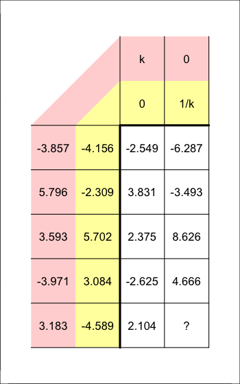

   What is the new y coordinate when point $(3.183, -4.589)$ undergoes the squeeze transformation with $k=0.661$?

#### Question

5. A video-game developer is hoping to apply a [squeeze map](https://en.wikipedia.org/wiki/Squeeze_mapping) to a set of points by using matrix multiplication. Interestingly, during a squeeze map, the area remains constant.

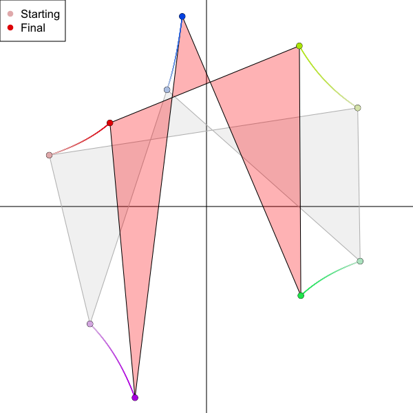

   The starting points are stored as rows in a 5 $\times$ 2 matrix $S$.

   $$S=\begin{bmatrix}
   -5.724 & 1.868\\
   5.503 & 3.59\\
   5.593 & -1.992\\
   -1.438 & 4.249\\
   -4.24 & -4.273
   \end{bmatrix}$$

   The squeeze matrix can be found by using $k=0.614$ in the formula below.

   $$T~=~\begin{bmatrix}
   k & 0\\
   0 & 1/k
   \end{bmatrix}$$

   The final points (in matrix $F$) are found by multiplying $S\cdot T$.

   $$F=S\cdot T$$

   That multiplication can be done using the diagram below.

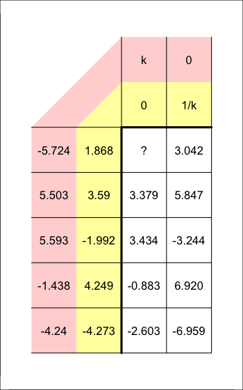

   What is the new x coordinate when point $(-5.724, 1.868)$ undergoes the squeeze transformation with $k=0.614$?

#### Question

6. A video-game developer is hoping to apply a [squeeze map](https://en.wikipedia.org/wiki/Squeeze_mapping) to a set of points by using matrix multiplication. Interestingly, during a squeeze map, the area remains constant.

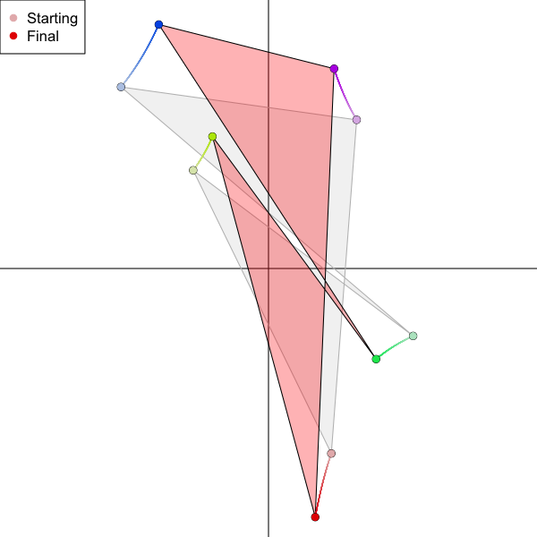

   The starting points are stored as rows in a 5 $\times$ 2 matrix $S$.

   $$S=\begin{bmatrix}
   1.997 & -5.881\\
   -2.395 & 3.122\\
   4.598 & -2.144\\
   -4.689 & 5.772\\
   2.803 & 4.727
   \end{bmatrix}$$

   The squeeze matrix can be found by using $k=0.744$ in the formula below.

   $$T~=~\begin{bmatrix}
   k & 0\\
   0 & 1/k
   \end{bmatrix}$$

   The final points (in matrix $F$) are found by multiplying $S\cdot T$.

   $$F=S\cdot T$$

   That multiplication can be done using the diagram below.

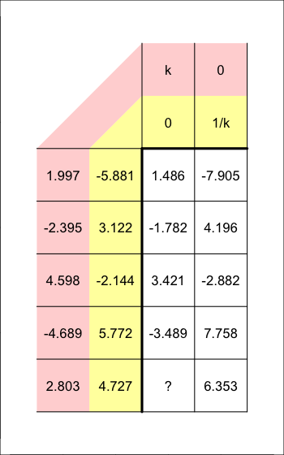

   What is the new x coordinate when point $(2.803, 4.727)$ undergoes the squeeze transformation with $k=0.744$?

#### Question

7. A video-game developer is hoping to apply a [squeeze map](https://en.wikipedia.org/wiki/Squeeze_mapping) to a set of points by using matrix multiplication. Interestingly, during a squeeze map, the area remains constant.

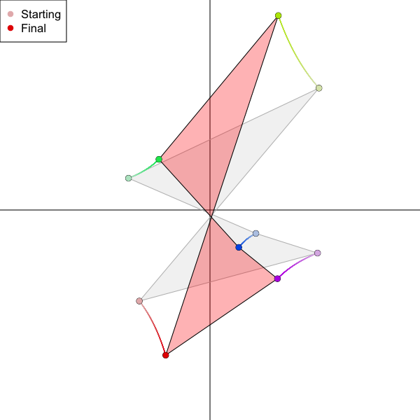

   The starting points are stored as rows in a 5 $\times$ 2 matrix $S$.

   $$S=\begin{bmatrix}
   -3.355 & -4.325\\
   5.176 & 5.791\\
   -3.871 & 1.51\\
   2.18 & -1.113\\
   5.11 & -2.046
   \end{bmatrix}$$

   The squeeze matrix can be found by using $k=0.627$ in the formula below.

   $$T~=~\begin{bmatrix}
   k & 0\\
   0 & 1/k
   \end{bmatrix}$$

   The final points (in matrix $F$) are found by multiplying $S\cdot T$.

   $$F=S\cdot T$$

   That multiplication can be done using the diagram below.

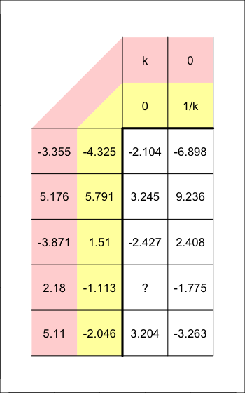

   What is the new x coordinate when point $(2.18, -1.113)$ undergoes the squeeze transformation with $k=0.627$?

#### Question

8. A video-game developer is hoping to apply a [squeeze map](https://en.wikipedia.org/wiki/Squeeze_mapping) to a set of points by using matrix multiplication. Interestingly, during a squeeze map, the area remains constant.

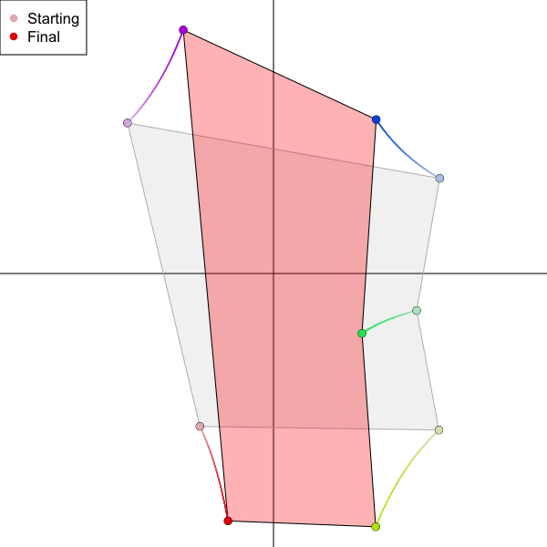

   The starting points are stored as rows in a 5 $\times$ 2 matrix $S$.

   $$S=\begin{bmatrix}
   -2.268 & -4.71\\
   5.097 & -4.821\\
   4.41 & -1.14\\
   5.121 & 2.931\\
   -4.499 & 4.637
   \end{bmatrix}$$

   The squeeze matrix can be found by using $k=0.618$ in the formula below.

   $$T~=~\begin{bmatrix}
   k & 0\\
   0 & 1/k
   \end{bmatrix}$$

   The final points (in matrix $F$) are found by multiplying $S\cdot T$.

   $$F=S\cdot T$$

   That multiplication can be done using the diagram below.

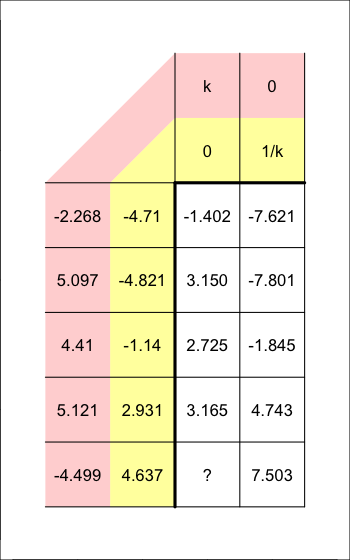

   What is the new x coordinate when point $(-4.499, 4.637)$ undergoes the squeeze transformation with $k=0.618$?